# Unidade I – Modelos de Variação Espacial

**Temas**: A variação espacial e os fatores que a determinam. Introdução à modelagem de dados espaciais. O modelo discreto de explicação da variação espacial. As visões determinística e estocástica do modelo discreto de variação espacial. O modelo contínuo de variação espacial. A visão determinística do modelo contínuo de variação espacial.

# 1 Introdução à modelagem espacial

Natureza da variação espacial

# 2 Modelo discreto de variação espacial

## 2.1 Modelo discreto: visão determinística

```r
# Pacotes
library(magrittr)
library(dplyr)
library(glue)
library(lattice)

# Sistemas de referência de coordenadas (Fonte: http://spatialreference.org/ref/epsg/)
wgs84utm22s <- sp::CRS('+proj=utm +zone=22 +south +ellps=WGS84 +datum=WGS84 +units=m +no_defs')
sirgas2000 <- sp::CRS('+proj=longlat +ellps=GRS80 +towgs84=0,0,0,0,0,0,0 +no_defs')

# Rampas de cores
col_soil_var <- topo.colors(100)
```

$$Solo = f(cl, o, r, p, t, \ldots)$$

Vejamos um exemplo de mapa pedológico produzido usando o modelo discreto de variação espacial em sua visão determinística. Para isso será preciso descarregar os arquivos do mapa pedológico para um diretório local. O nome desse diretório é definido abaixo pelo objeto `data_folder`. Altere o caminho para esse diretório conforme necessário. Caso você já tenha descarregado os arquivos do mapa pedológico, então `data_folder` deve ser o caminho para o diretório onde esses arquivos se encontram.

```r
data_folder <- '../data/'
ext <- c('dbf', 'prj', 'shp', 'shx')
files <- glue('pedologia25.{ext}')
download <- !all(files %in% list.files(data_folder))
if (download) {
  url <- 'https://github.com/samuel-rosa/UFSM-SOL-843/tree/master/data/'
  url <- glue('{url}{files}')
  destfile <- glue('{data_folder}{files}')
  for (i in 1:length(files)) {
    download.file(url = url[i], destfile = destfile[i])
  }
}
```

Agora você já pode carregar o mapa pedológico para o seu ambiente de trabalho. Para isso, use a função `raster::shapefile`. Note que se o sistema operacional do seu computador for o MS Windows, pode ser necessário incluir o o argumento `encoding = 'UTF-8'` na função `raster::shapefile` para garantir que os carácteres especiais usados nos nomes das unidades de mapeamento seja reconhecidos. Verifique se a estrutura de `pedologia25` está conforme o esperado para um objeto do tipo `SpatialPolygonsDataFrame`. Note que a função `sp::spTransform` é usada para projetar as coordenadas original no plano cartesiano (UTM).

```r
pedologia25 <-
  glue('{data_folder}pedologia25.shp') %>%
  raster::shapefile(stringsAsFactors = TRUE) %>%
  sp::spTransform(wgs84utm22s)
str(pedologia25, 2)
```

```
## Formal class 'SpatialPolygonsDataFrame' [package "sp"] with 5 slots
##   ..@ data       :'data.frame':  25 obs. of  1 variable:
##   ..@ polygons   :List of 25
##   ..@ plotOrder  : int [1:25] 12 8 11 5 6 18 24 10 22 23 ...
##   ..@ bbox       : num [1:2, 1:2] 226655 6715750 231890 6721725
##   .. ..- attr(*, "dimnames")=List of 2
##   ..@ proj4string:Formal class 'CRS' [package "sp"] with 1 slot
```

O próximo passo consiste em produzir uma figura de `pedologia25`. Para isso usamos a função `sp::spplot`, criada especificamente para a produção de figuras de objetos espaciais. Antes disso, vamos criar uma rampa de cores específica para `pedologia25`, a qual será constituída de tantas cores quantas foram as unidades de mapeamento. Vejamos o resultado na Figura 2.1.

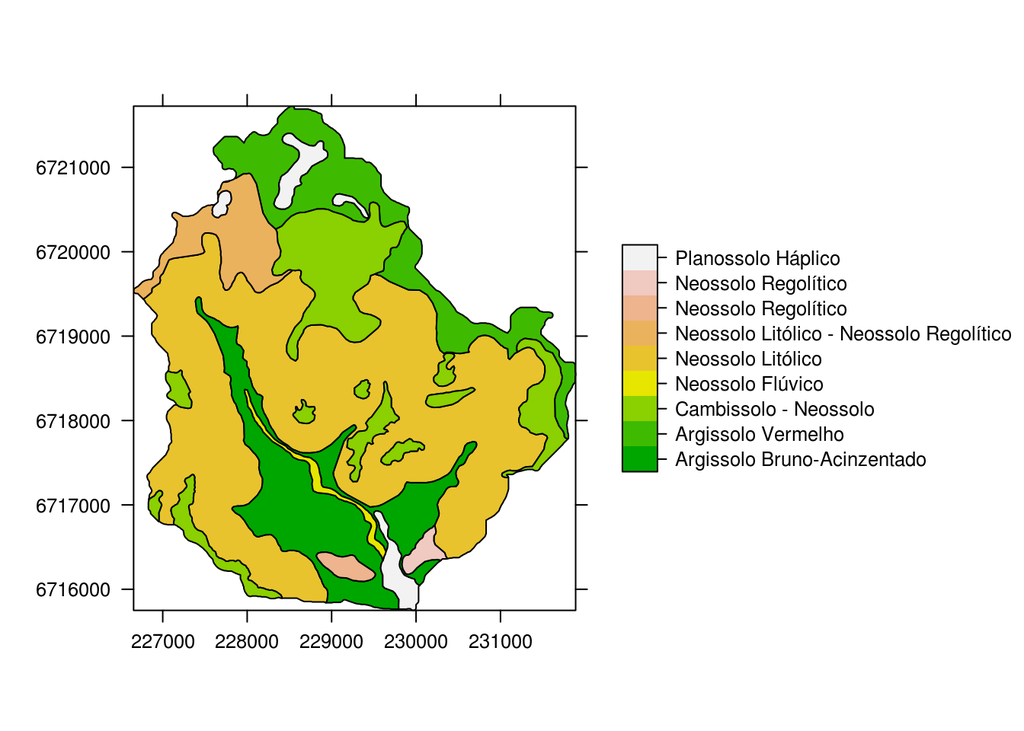

Figure 2.1: Mapa pedológico preparado na escala cartográfica de 1:25000 e suas nove unidades de mapeamento.

```r
col_soil_um <- terrain.colors(nlevels(pedologia25$um))
sp::spplot(pedologia25, scales = list(draw = TRUE), col.regions = col_soil_um)
```

Descarregar dados do conjunto de dados `ctbo0030`:

```r
perfis25_o <- febr::observations('ctb0030', which.cols = 'all')
perfis25_l <- febr::layers('ctb0030', which.cols = 'all', missing.data = 'keep')
id <- c('dataset_id', 'observacao_id')
perfis25 <-
  merge(x = perfis25_o, y = perfis25_l, by.x = id, by.y = id) %>%
  select(observacao_id, coord_x, coord_y, taxon_sibcs_2009, ca_kcl_aas, areia_, argila_)
rm(perfis25_l, perfis25_o)
```

Criar objeto espacial com os perfis e gerar figura.

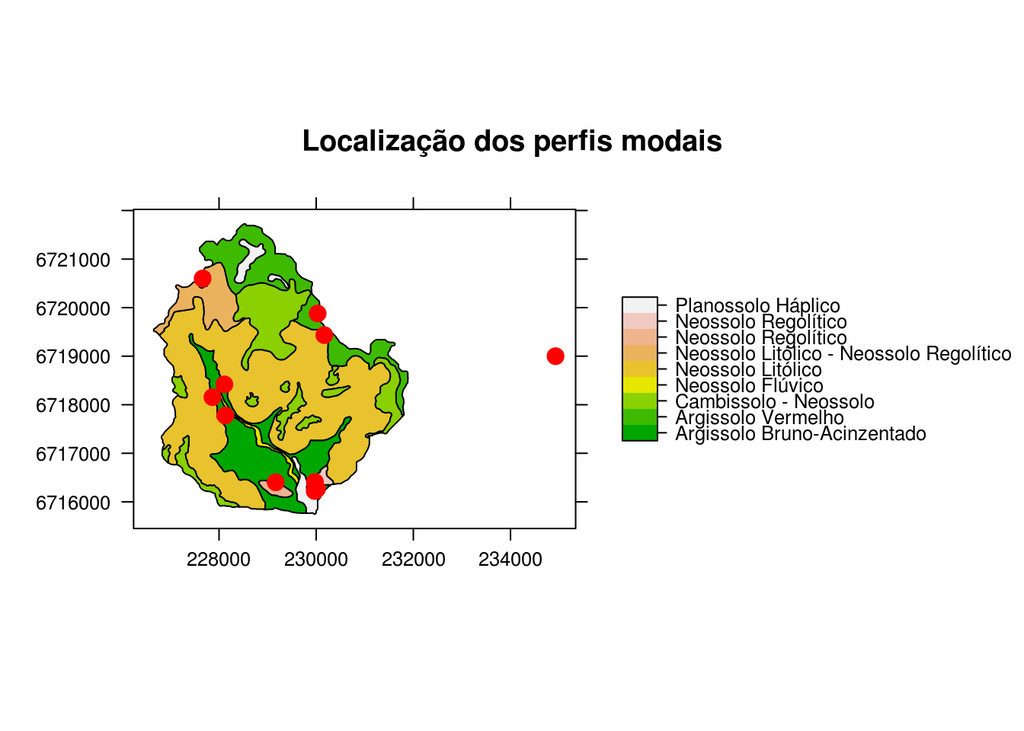

[output not shown]

```r
sp::coordinates(perfis25) <- c('coord_x', 'coord_y')
sp::proj4string(perfis25) <- sirgas2000
perfis25 <- sp::spTransform(perfis25, wgs84utm22s)
sp::spplot(
  pedologia25, scales = list(draw = TRUE),
  xlim = extendrange(c(perfis25@bbox[1, ], pedologia25@bbox[1, ])),
  ylim = extendrange(c(perfis25@bbox[2, ], pedologia25@bbox[2, ])),
  col.regions = terrain.colors(nlevels(pedologia25$um)),
  main = "Localização dos perfis modais") +
  lattice::xyplot(coord_y ~ coord_x, data = as.data.frame(perfis25@coords),
                  pch = 20, col = 'red', lwd = 2, cex = 2) %>%
  latticeExtra::as.layer()
```

## 2.2 Modelo discreto: visão estocástica

```r
pontos400_o <- febr::observations('ctb0003', which.cols = 'all')
pontos400_l <- febr::layers('ctb0003', which.cols = 'all', missing.data = 'keep')
id <- c('dataset_id', 'observacao_id')
pontos400 <-
  merge(pontos400_o, pontos400_l, by.x = id, by.y = id) %>%
  select(observacao_id, coord_x, coord_y, taxon_sibcs_2009, ca_kcl_aas, argila_, areia_)
rm(pontos400_l, pontos400_o)
```

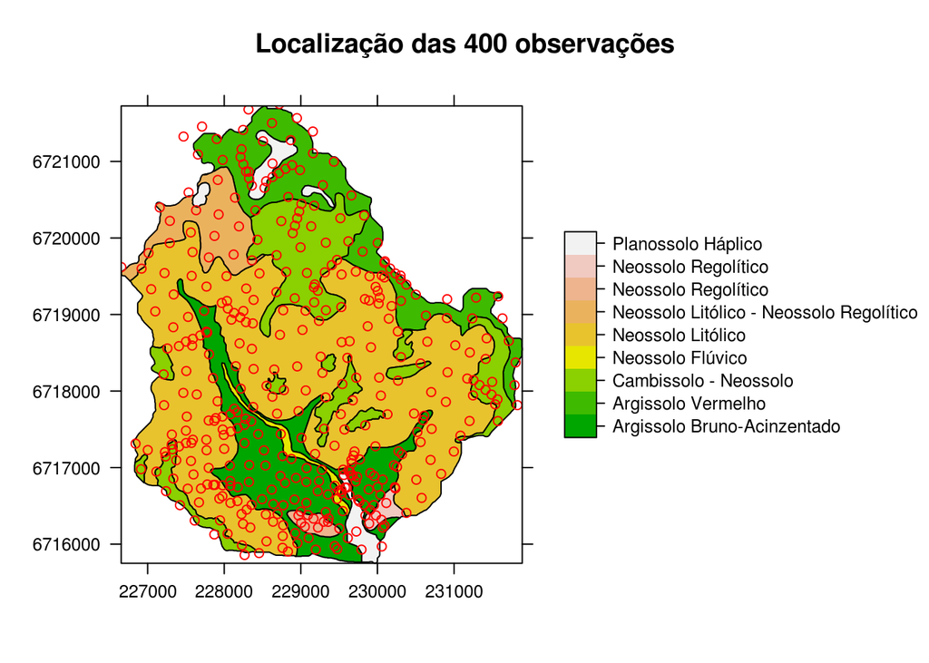

```r
sp::coordinates(pontos400) <- ~ coord_x + coord_y
sp::proj4string(pontos400) <- sirgas2000
pontos400 <- sp::spTransform(pontos400, wgs84utm22s)
sp::spplot(
  pedologia25, scales = list(draw = TRUE),
  col.regions = terrain.colors(nlevels(pedologia25$um)),
  main = "Localização das 400 observações") +
  lattice::xyplot(coord_y ~ coord_x,
                  data = pontos400@coords %>% as.data.frame(), pch = 21, col = 'red') %>%
  latticeExtra::as.layer()
```

Nós podemos calcular a média e desvio padrão da variável de interesse para cada categoria a partir das observações do solo que estão dentro de cada categoria. Mas primeiro temos que identificar a categoria dentro da qual cada observação do solo se encontra. Para isso usamos a função `sp::over` e armazenamos o resultado em uma nova coluna de `pontos400` chamada `um`. Assumindo que nossa amostra é grande o suficiente, que as observações são independetes, e que a variável de interesse possui distribuição nomal, calculamos o erro padrão (EP) da média para obter os limites inferior e superior do intervalo de confiança de 95%.

Calcular estatísticas de uma variável do solo para cada unidade de mapeamento.

```r
pontos400$um <- sp::over(x = pontos400, y = pedologia25) %>% unlist()
pontos400@data %>%
  filter(!is.na(um)) %>%
  group_by(um) %>%
  summarise(
    media = mean(areia_),
    ic95 = 1.96 * sd(areia_) / sqrt(n()),
    n = n()) %>%
  mutate(
    inf = round(media - ic95),
    media = round(media),
    sup = round(media + ic95)) %>%
  select(um, inf, media, sup, n)
```

```
## # A tibble: 9 x 5
##                                         um   inf media   sup     n
##                                     <fctr> <dbl> <dbl> <dbl> <int>
## 1              Argissolo Bruno-Acinzentado   728   749   771    80
## 2                       Argissolo Vermelho   221   238   254    38
## 3                    Cambissolo - Neossolo   262   304   346    49
## 4                         Neossolo Flúvico   768   864   959     2
## 5                        Neossolo Litólico   513   552   591   169
## 6 Neossolo Litólico - Neossolo Regolítico   227   261   295    13
## 7                      Neossolo Regolítico   531   600   670     8
## 8                     Neossolo Regolítico   813   859   905     4
## 9                       Planossolo Háplico   320   465   609    13
```

Vamos comparar o resultado acima com os valores obtidos diretamente dos perfis modais. Será que os dados produzidos a partir dos perfis modais encontram-se dentro do intervalo de confiança de 95% da média estimada acima?

```r
perfis25@data %>%
  select(taxon_sibcs_2009, areia_) %>%
  arrange(taxon_sibcs_2009)
```

```
##                                 taxon_sibcs_2009 areia_
## 1  Argissolo Bruno-Acinzentado Alítico abrúptico    823
## 2              Argissolo Vermelho Alítico típico    199
## 3         Cambissolo Háplico Ta Eutrófico típico    843
## 4     Neossolo Flúvico Tb Eutrófico fragmentário    750
## 5        Neossolo Litólico Distro-úmbrico típico    266
## 6        Neossolo Litólico Distro-Úmbrico típico    534
## 7         Neossolo Litólico Eutro-úmbrico típico    847
## 8      Neossolo Regolítico Distro-Úmbrico típico    763
## 9      Neossolo Regolítico Distro-Úmbrico típico    669
## 10     Neossolo Regolítico Distro-Úmbrico típico    635
## 11             Planossolo Háplico Alítico típico     60
```

# 3 Modelo contínuo de variação espacial

## 3.1 Modelo contínuo: visão determinística

Modelos digitais de elevação: http://www.scielo.br/img/revistas/rbcs/v40//0100-0683-rbcs-18069657rbcs20150022-gf02.jpg

Perfil topográfico de modelos digitais de elevação: http://www.scielo.br/img/revistas/rbcs/v40//0100-0683-rbcs-18069657rbcs20150022-gf03.jpg

Interpolação determinística usando o inverso da distância como peso da influência das observações vizinhas.

```r
grid <- sp::spsample(pedologia25, 10000, type = 'regular')
modelo_idw <- gstat::gstat(
  id = 'argila', formula = argila_ ~ 1,
  data = pontos400, nmax = 8, set = list(idp = 0.5))
mapa_idw <- predict(modelo_idw, grid)
```

```
## [inverse distance weighted interpolation]
```

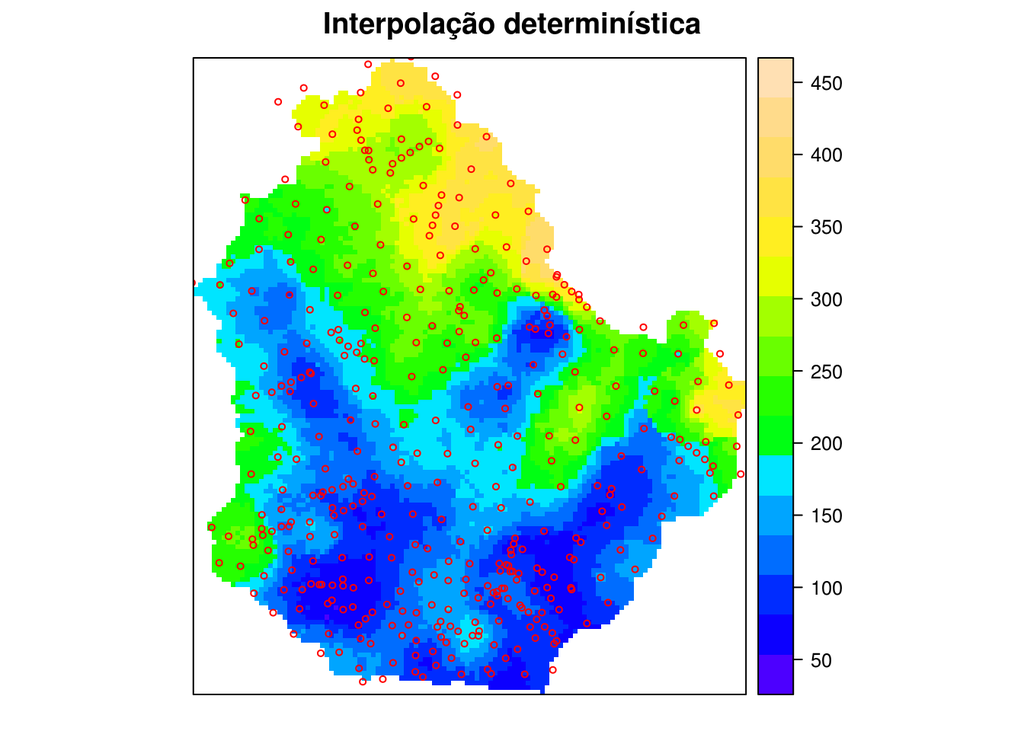

```r
sp::gridded(mapa_idw) <- TRUE
sp::spplot(mapa_idw, 'argila.pred', col.regions = col_soil_var,
           main = "Interpolação determinística") +
  latticeExtra::as.layer(lattice::xyplot(
    coord_y ~ coord_x, data = pontos400@coords %>% as.data.frame(),
    pch = 21, col = 'red', cex = 0.5))
```